# TIME SERIES INTRODUCTION

Irene Knecht

1 July 2016

## TIME SERIES

The energy consumption depends on the time. The measurement of energy consumption is carried out sequentially. The values are taken over a continuous time interval. Sometimes the energy consumption will be measured every 10 minutes and sometimes only once per year.

### 2 HOURS PATH TIME SERIE OF ONE WEEK

#### DATA

```r
days <- rep(c("monday","tuesday","wednesday","thursday","friday","saturday","sunday"), each=120)
time <- rep(rep(paste(seq(0,22,2), seq(2,24,2), sep="-"), each=10),7)
value <- abs(rnorm(mean=10, sd=10,length(time)))
data <- data.frame(days, time, value)
```

Here can you see how the data frame looks like.

```r
head(data)
```

```
##     days time     value
## 1 monday  0-2  4.978608
## 2 monday  0-2  2.127833
## 3 monday  0-2 10.969179
## 4 monday  0-2  3.716657
## 5 monday  0-2 24.808805
## 6 monday  0-2  9.104850
```

```r
str(data)
```

```
## 'data.frame':    840 obs. of  3 variables:
##  $ days : Factor w/ 7 levels "friday","monday",..: 2 2 2 2 2 2 2 2 2 2 ...
##  $ time : Factor w/ 12 levels "0-2","10-12",..: 1 1 1 1 1 1 1 1 1 1 ...
##  $ value: num  4.98 2.13 10.97 3.72 24.81 ...
```

#### VISUALITAZION

To make a nice visualization I recommend to use *RColorBrewer* for colorize the plot.

```r
library(RColorBrewer)
my_colors <- brewer.pal(9, "Blues")
my_colors <- colorRampPalette(my_colors)(12)
```

Now I calculate the average value of the different days and time paths with dplyr.

```r
library(dplyr)
data_avg <- data%>%
  group_by(days,time)%>%
  summarise(value=mean(value))%>%
  ungroup()
```

Finally I make a box plot and add the average as a trend line.

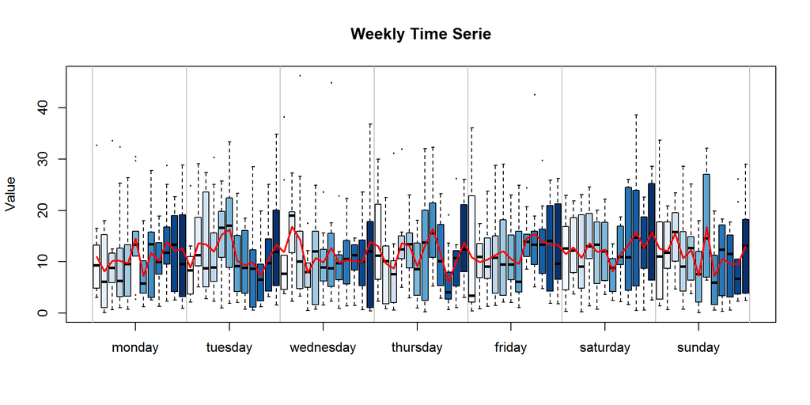

```r
par(mfrow=c(1,1))
boxplot(data$value ~ data$time+data$days , xaxt="n" , xlab="" , col=my_colors , pch=20 , cex=0.3 , ylab="Value", main="Weekly Time Serie" )
abline(v= seq(0, 12*7, 12) +0.5 , col="grey")
axis(1, labels=unique(days) , at=seq(6,12*7,12) )
lines(data_avg$value, col="red", lwd=2)
```

### MONTHLY TIME SERIE

#### DATA

```r
month <- as.factor(rep(seq(1,12,1),times=3))
value <- abs(rnorm(mean=10, sd=20,length(month)))+
  c(608,520,440,313,114,50,4,12,82,264,470,562)
year <- rep(c("2013","2014","2015"), each=12)
data <- data.frame(year, month, value)
```

Here can you see how the data frame looks like.

```r
head(data)
```

```
##   year month     value
## 1 2013     1 644.32088
## 2 2013     2 533.85229
## 3 2013     3 475.69691
## 4 2013     4 317.09733
## 5 2013     5 121.15126
## 6 2013     6  60.28336
```

```r
str(data)
```

```
## 'data.frame':    36 obs. of  3 variables:
##  $ year : Factor w/ 3 levels "2013","2014",..: 1 1 1 1 1 1 1 1 1 1 ...
##  $ month: Factor w/ 12 levels "1","2","3","4",..: 1 2 3 4 5 6 7 8 9 10 ...
##  $ value: num  644 534 476 317 121 ...
```

#### VISUALITAZION

```r
library(ggplot2)
```

I visualize the data in a grouped barplot. The bars are grouped by the months and colored by the year.

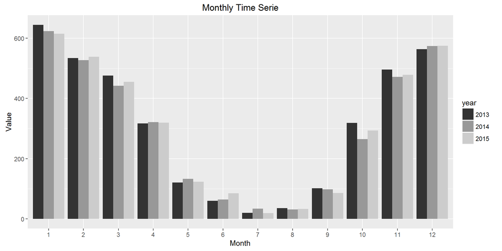

```r
ggplot(data, aes(month,value, fill=year))+
  geom_bar(stat="identity", position="dodge")+
  labs(title="Monthly Time Serie", x="Month", y= "Value")+
  scale_fill_grey()
```

### YEARLY TIME SERIE

#### DATA

```r
year <- as.factor(rep(seq(2006,2015,1),times=4))
value <- rnorm(mean=3440, sd=100,length(year))
building <- rep(c("A","B","C", "D"), each=10)
data <- data.frame(year, building, value)
```

Here can you see how the data frame looks like.

```r
head(data)
```

```
##   year building    value
## 1 2006        A 3394.082
## 2 2007        A 3326.335
## 3 2008        A 3486.330
## 4 2009        A 3489.955
## 5 2010        A 3526.722
## 6 2011        A 3445.438
```

```r
str(data)
```

```
## 'data.frame':    40 obs. of  3 variables:
##  $ year    : Factor w/ 10 levels "2006","2007",..: 1 2 3 4 5 6 7 8 9 10 ...
##  $ building: Factor w/ 4 levels "A","B","C","D": 1 1 1 1 1 1 1 1 1 1 ...
##  $ value   : num  3394 3326 3486 3490 3527 ...
```

#### VISUALITAZION

```r
library(ggplot2)
```

I visualize the data in a grouped barplot. The bars are grouped by the year and colored by the building.

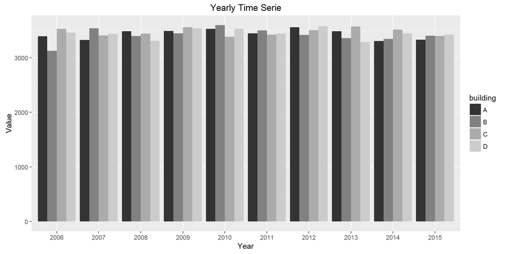

```r
ggplot(data, aes(year,value, fill=building))+
  geom_bar(stat="identity", position="dodge")+
  labs(title="Yearly Time Serie", x="Year", y= "Value")+
  scale_fill_grey()
```